# 13.Example 1

Modified

Mo 2026-09-21 21:39

## Given:

A diffuse surface at $1600\ \mathrm{K}$ has the spectral, hemispherical emissivity shown as follows.

Figure 1: Spectral, Hemispherical Emissivity

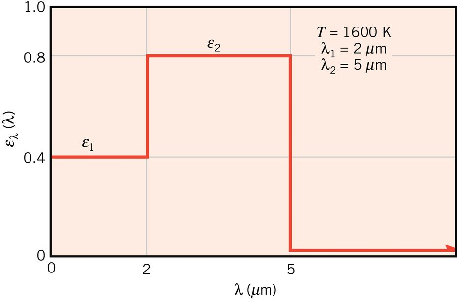

## Required:

Determine the total, hemispherical emissivity and the total emissive power.

## Solution:

Start first by defining all of the given values.

$$T = 1600\ \mathrm{K}$$
$$\varepsilon_1 = 0.4$$
$$\varepsilon_2 = 0.8$$
$$\varepsilon_3 = 0$$
$$\lambda_1 = 2\ \mathrm{μm}$$
$$\lambda_2 = 5\ \mathrm{μm}$$

Other known quantities that will be used are shown below.

$$\sigma = 5.67\times 10^{-8}\ \frac{\mathrm{W}}{\left(\mathrm{K}^{4} \cdot \mathrm{m}^{2}\right)}$$

The total, hemispherical emissivity is given by the expression shown below.

$$\varepsilon = \frac{\int_0^\infty \varepsilon_\lambda E_{\lambda, b} d \lambda}{E_b}$$

The integral in the numerator may be split into the different sections from the plot given in the problem statement. This new expression is shown below.

$$\varepsilon = \frac{\int_0^{\lambda_1} \varepsilon_1 E_{\lambda, b} d \lambda}{E_b} + \frac{\int_{\lambda_1}^{\lambda_2} \varepsilon_2 E_{\lambda, b} d \lambda}{E_b} + \frac{\int_{\lambda_2}^\infty \varepsilon_\lambda E_{\lambda, b} d \lambda}{E_b}$$

The last term in the expression above goes to zero because the emissivity in that interval is zero (this may be seen from the plot given in the problem statement). The emissivity terms in in the other two integrals are constants so they be taken out of the integral.

$$\varepsilon = \frac{\varepsilon_1 \int_0^{\lambda_1} E_{\lambda, b} d \lambda}{E_b} + \frac{\varepsilon_2 \int_{\lambda_1}^{\lambda_2} E_{\lambda, b} d \lambda}{E_b}$$

$$\varepsilon = \varepsilon_1 F_{0\rightarrow \lambda_1} + \varepsilon_2 F_{\lambda_1 \rightarrow \lambda_2}$$

The above expression may be further simplified by recognizing that $F_{\lambda_1 \rightarrow \lambda_2}$ is the difference between $F_{0 \rightarrow \lambda_2}$ and $F_{0 \rightarrow \lambda_1}$. This simplification is shown below.

$$\varepsilon = \varepsilon_1 F_{0\rightarrow \lambda_1} + \varepsilon_2 \left( F_{0 \rightarrow \lambda_2} - F_{0 \rightarrow \lambda_1} \right)$$

To use Table 9, the product of the temperature and wavelength are needed. The operation is shown below.

$$(\lambda T)_1 = \lambda_1 T = 3200\ \mathrm{K} \cdot \mathrm{μm}$$

$$(\lambda T)_2 = \lambda_2 T = 8000\ \mathrm{K} \cdot \mathrm{μm}$$

The second value may be read directly from Table 9.

$$F_{0 \rightarrow \lambda_2} = 0.856288$$

The total emissivity is then

Answer, part 1: $\varepsilon = \varepsilon_1 F_{0 \rightarrow \lambda_1} + \varepsilon_2 ( F_{ 0 \rightarrow \lambda_2} - F_{ 0 \rightarrow \lambda_1}) = 0.558037$

The total emissive power is then

Answer, part 2: $E = \varepsilon \sigma T^4 = 207.4\ \frac{\mathrm{kW}}{\mathrm{m}^{2}}$